# 00B - R Configuration

Emma Bell

2020-04-22

# Summary

This R Notebook contains code pertaining to the paper Loo and Bell *et al.* (2020).

- Aim: To configure my R environment.
- Objectives:
  1. Create objects specifying the path to commonly referenced directories;
  2. Create objects specifying the parameters for generating figures;
  3. Create an object specifying the colour scheme used in figures.

To run these scripts we assume a directory structure as described in the README accompanying this GitHub. I.e.

- code/ - *contains R Notebook(s) and the resulting HTML file(s)*
  - 00A - Sequencing read pre-processing
  - 00B - R configuration
  - RRBS_01 - Sequencing read alignment with Bismark
  - RRBS_02 - Calling base level methylation with MethylKit
  - RRBS_03 - Calculating differential methylation with MethylKit
  - RRBS_04 - Defining hypomethylated windows for HOMER motif enrichment
  - ATAC_05 - Calling nucleosome-free regions with MACS2
  - ATAC_06 - Quantifying nucleosome-free regions
  - ATAC_07 - Defining nucleosome-free regions unique to the DAC sample group for HOMER motif enrichment
  - RNA_08 - Quantifying transcript expression with Kallisto
  - RNA_09 - Calling differential transcript expression with Sleuth
  - RNA_10 - Gene-set enrichment with CensensusPathDB and limma
- data/ - *contains any data used in this project*
  - 01_raw/
  - 02_clean/
  - 03_augmented/
- docs/ - *contains any documents pertaining to this project*
  - Presentation_plan_template.docx
  - Presentation_template.pptx
  - Research_project_plan.docx
- results/ - *contains results files*
  - docs/
  - figures/
  - tables/

## 1. Create objects specifying the path to commonly referenced directories

The parent directory for this project is `2020_LooBell`.

```r
code.dir <- file.path("code")
data.dir <- file.path("data")
clean.data.dir <- file.path(data.dir,"02_clean")
augmented.data.dir <- file.path(data.dir,"03_augmented")
docs.dir <- file.path("docs")
results.dir <- file.path("results")
figure.dir <- file.path(results.dir,"figures")
table.dir <- file.path(results.dir,"tables")

dirs <- list(code.dir=code.dir,data.dir=data.dir,clean.data.dir=clean.data.dir,augmented.data.dir=augmented.data.dir,docs.dir=docs.dir,results.dir=results.dir,figure.dir=figure.dir,table.dir=table.dir)
dirs
```

```
## $code.dir
## [1] "code"
##
## $data.dir
## [1] "data"
##
## $clean.data.dir
## [1] "data/02_clean"
##
## $augmented.data.dir
## [1] "data/03_augmented"
##
## $docs.dir
## [1] "docs"
##
## $results.dir
## [1] "results"
##
## $figure.dir
## [1] "results/figures"
##
## $table.dir
## [1] "results/tables"
```

## 2. Create objects specifying the parameters for generating figures

All figures are outputted to the following specifications:

```r
units <- "cm"
width <- 6
height <- 6
res <- 480
pointsize <- 6

fig.specs <- list(units=units,width=width,height=height,res=res,pointsize=pointsize)
fig.specs
```

```
## $units
## [1] "cm"
##
## $width
## [1] 6
##
## $height
## [1] 6
##
## $res
## [1] 480
##
## $pointsize
## [1] 6
```

## 3. Create an object specifying the colour scheme used in figures

This R Notebook requires the following packages:

```r
library(viridis)
```

The colour scheme used in this R Notebook is as follows:

```r
pal <- inferno(n = 9, begin = 0.2, end = 0.8)
pal2 <- inferno(n = 9, begin = 0.2, end = 0.8, alpha = 0.5)

fig.cols <- list(
    Donor = c(`Donor 1`=pal2[1], `Donor 2`=pal[1], `Donor 3`=pal[2]),
    Stimulated = c(Unstimulated="#DEA3AF",Stimulated=pal[5]),
    DAC = c(Untreated="lightgrey",Treated=pal[7]))
fig.cols
```

```
## $Donor
##     Donor 1     Donor 2     Donor 3
## "#420A6880" "#420A68FF" "#61136EFF"
##
## $Stimulated
## Unstimulated   Stimulated
##    "#DEA3AF"  "#BB3754FF"
##
## $DAC
##   Untreated     Treated
## "lightgrey" "#EA632AFF"
```

```r
simple.cols <- unlist(fig.cols)[c(4,5,7)]
simple.cols
```

```
## Stimulated.Unstimulated   Stimulated.Stimulated             DAC.Treated
##               "#DEA3AF"             "#BB3754FF"             "#EA632AFF"
```

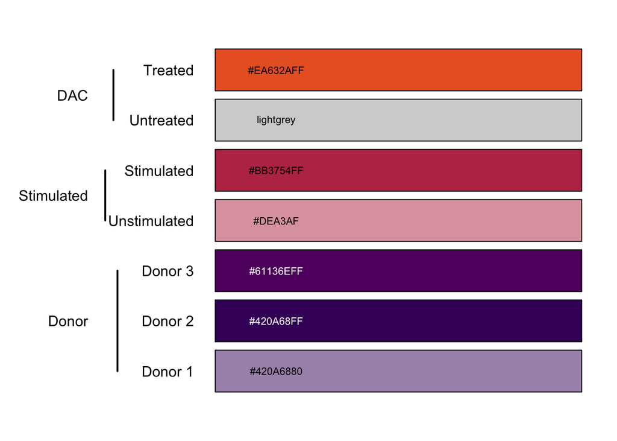

```r
names.arg <- unlist(sapply(X = fig.cols, FUN = function(X) names(X)))
side.names <- names(fig.cols)

par(mar = c(2,12,2,2), xpd = TRUE)
bp <- barplot(height = rep(x = 9, times = length(unlist(fig.cols))), col = unlist(fig.cols), names.arg = names.arg, horiz = TRUE, las = 1, axes = FALSE)
side.y <- c(mean(bp[1:3,1]),mean(bp[4:5,1]),mean(bp[6:7]))
text(x = 1.5, y = bp[,1], labels = unlist(fig.cols), cex = 0.7, col = rep(c("black","white","black"),c(1,2,4)))
mtext(text = side.names, side = 2, las = 1, line = 7, at = side.y)
lines(x = c(-2.4,-2.4), y = bp[c(1,3),1], xpd = TRUE, lwd = 2)
lines(x = c(-2.7,-2.7), y = bp[c(4,5),1], xpd = TRUE, lwd = 2)
lines(x = c(-2.5,-2.5), y = bp[c(6,7),1], xpd = TRUE, lwd = 2)
```

```r
rm(pal,pal2,names.arg,side.names,side.y,bp)
```

```r
r.config <- list(dirs=dirs,fig.specs=fig.specs,fig.cols=fig.cols,simple.cols=simple.cols)
r.config
```

```
## $dirs
## $dirs$code.dir
## [1] "code"
##
## $dirs$data.dir
## [1] "data"
##
## $dirs$clean.data.dir
## [1] "data/02_clean"
##
## $dirs$augmented.data.dir
## [1] "data/03_augmented"
##
## $dirs$docs.dir
## [1] "docs"
##
## $dirs$results.dir
## [1] "results"
##
## $dirs$figure.dir
## [1] "results/figures"
##
## $dirs$table.dir
## [1] "results/tables"
##
##
## $fig.specs
## $fig.specs$units
## [1] "cm"
##
## $fig.specs$width
## [1] 6
##
## $fig.specs$height
## [1] 6
##
## $fig.specs$res
## [1] 480
##
## $fig.specs$pointsize
## [1] 6
##
##
## $fig.cols
## $fig.cols$Donor
##     Donor 1     Donor 2     Donor 3
## "#420A6880" "#420A68FF" "#61136EFF"
##
## $fig.cols$Stimulated
## Unstimulated   Stimulated
##    "#DEA3AF"  "#BB3754FF"
##
## $fig.cols$DAC
##   Untreated     Treated
## "lightgrey" "#EA632AFF"
##
##
## $simple.cols
## Stimulated.Unstimulated   Stimulated.Stimulated             DAC.Treated
##               "#DEA3AF"             "#BB3754FF"             "#EA632AFF"
```

```r
saveRDS(object = r.config, file = file.path(dirs$code.dir,"r_config.RDS"))
```